# Section analysis, number of works

Adam Finnemann

September 21, 2017

Question: How many people were there overall in the section over time. This is answered by extracting all observations were “Section” is part of the fname.

```r
section_worker <- da %>%
  filter(str_detect(da$fname, "Section"))
```

Calculating how many different people there were in the Section.

```r
section_worker %>%
  filter(!duplicated(id)) %>%
  nrow
```

```
## [1] 266
```

There are a total 362 observations of “Section” in the fname column. These comes from 266 different people.

The distrbution of Section fnames is found (some of these are from the same persons)

```r
section_worker <- droplevels(section_worker)

summary(section_worker$fname)
```

```
## Assistant Head of Section          Chief of Section
##                         8                        17
##           Head of Section         Member of Section
##                         8                       323
##      Secretary of Section
##                         6
```

Preparations for calculating number of people in section over time

```r
mdl_df <- section_worker %>%
  select(pname, fname_code,begin_date, end_date) %>%
  mutate(begin_date = as.Date(begin_date),
         end_date = as.Date(end_date))



setDT(mdl_df)[
  # right join with sequence of monthly intervals
  .(mseq = seq(as.Date("1944-01-01"), length.out = 4L, by = "1 month")),
  # using non-equi join conditions
  on = .(begin_date <= mseq, end_date >= mseq)][
    # reshape from wide to long format,
    # show rank (concatenate in case of multiple ranks)
    , dcast(unique(.SD), pname ~ end_date, toString, value.var = "fname_code")]

result <- setDT(mdl_df)[
  .(mseq = seq(as.Date("1919-01-01"), as.Date("1948-12-30"), by = "1 month")),
  on = .(begin_date <= mseq, end_date >= mseq), nomatch = 0L, allow.cartesian = TRUE][
    , dcast(unique(.SD), pname ~ end_date, toString, value.var = "fname_code")]
```

It has 250 observations, meaning that 266-250 = 16 people from the section isn’t represented.

Here is a list of the 16 not included people. This is due to missing data points. I’ll create a table with all the missing data frames for all the section people in the last part of this document.

```r
left_out <- section_worker$pname[!(section_worker$pname %in% result$pname)]
unique(left_out)
```

```
##  [1] Harold Nicolson           John Leslie Palmer
##  [3] Salvador Madariga         Oscar Uno Konrad Thorsing
##  [5] Konstanty Symonolewicz    Viktorias Kamantanskas
##  [7] Ãke  HammarskjÃ¶ld       Johan Marie Frans Romein
##  [9] Evelyne Meylan            F. Geraldine Delf
## [11] Thomas Paterson           Elisabeth Delannoy
## [13] Manual Juan Arocha        Octave Auguste Arsandaux
## [15] John Pawley Bate          Henry Reginald Cummings
## 266 Levels:   Armi Inkeri Hallstein-Kallia ... Aarne Wuorimaa
```

```r
result[1:40,1:3]
```

```
##                                pname 1919-07-01 1919-08-01
##  1:     Armi Inkeri Hallstein-Kallia
##  2:                     Abdul Waheed
##  3:          Abol-Hassan Khan Hekimi
##  4:                    Adrianus Pelt
##  5:                    Alberto Berio
##  6:                Alexander Loveday          8          8
##  7:            Alexander Przychowsky
##  8:           Alfred Eduard Husslein
##  9:                Alfred von Suchan
## 10:                   Alfredo Blanco
## 11:        Amulya Chandra Chatterjee
## 12:               AndrÃ© D. Toledano
## 13:                     AndrÃ© Ganem
## 14:                    AndrÃ© Sayous
```

[output cut: 27 more lines]

Number of Section workers for each time period is calculated:

```r
removed <- result[,-1]

time_section <- matrix(nrow = (ncol(removed)), ncol = 1)

for (i in 1:(nrow(time_section))){
  time_section[i] = sum(removed[,i, with = F] != "")
}


dates <- as.character(colnames(removed))

plot.df <- cbind(time_section,dates) %>%
  as.data.frame() %>%
  mutate(dates = as.Date(dates),
         V1 = as.numeric(as.character(V1))) %>%
  rename(Section_Workers = V1)
```

The dataframe shown below contains the number of section workers per month for the 250 section members.

```r
plot.df
```

```
##     Section_Workers      dates
## 1                 2 1919-07-01
## 2                 3 1919-08-01
## 3                 6 1919-09-01
## 4                 9 1919-10-01
## 5                10 1919-11-01
## 6                10 1919-12-01
## 7                11 1920-01-01
## 8                12 1920-02-01
## 9                15 1920-03-01
## 10               18 1920-04-01
## 11               22 1920-05-01
## 12               24 1920-06-01
## 13               26 1920-07-01
## 14               30 1920-08-01
```

[output cut: 326 more lines]

The number of people in the section as a bar plot:

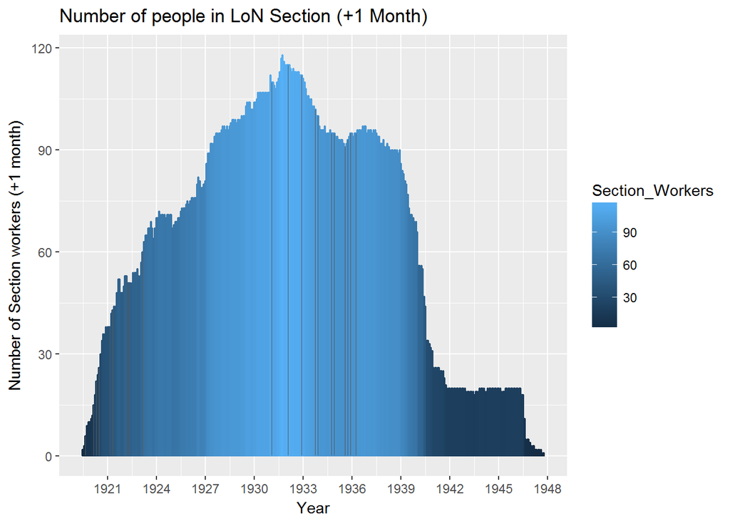

```r
plot.df %>%
  ggplot(aes(dates, Section_Workers, color = Section_Workers)) +
  geom_col()+
  labs(x = "Year", y ="Number of Section workers (+1 month)", titles ="Number of people in LoN Section (+1 Month)")+
  scale_x_date(date_breaks = "3 year", date_labels = "%Y")
```

Lastly I’ll make a list of the section workers that didn’t make it into the analysis due to missing dates.

```r
NAs <- filter(section_worker, is.na(section_worker$end_date) | is.na(section_worker$begin_date)) %>% select(pname, fname, begin_on_day, begin_on_month,begin_on_day, end_on_day,end_on_month, end_on_year )



#write.csv(NAs, "Section_workers_missing_data.csv")
NAs
```

```
##                          pname             fname begin_on_day
## 1         Solon George Xenakis Member of Section           21
## 2           Frank Paul Walters   Head of Section           10
## 3              Harold Nicolson Member of Section           21
## 4              Julian Nogueira Member of Section           28
## 5              Julian Nogueira Member of Section            1
## 6    William O'Sullivan-Molony Member of Section            1
## 7  EugÃ¨ne Henri RenÃ©  Vigier Member of Section            1
## 8           John Leslie Palmer Member of Section           10
## 9           John Leslie Palmer Member of Section            1
## 10          John Leslie Palmer Member of Section            1
## 11          Hugh McKinnon Wood Member of Section            1
## 12           Salvador Madariga Member of Section           22
## 13           Salvador Madariga  Chief of Section            1
## 14         Ãke  HammarskjÃ¶ld Member of Section           19
```

[output cut: 39 more lines]